# Physical Aactivity prediction based on data from wearable devices

Elena Chernousova

# Summary

The report presents the outcome on reseach of physical activities measured by wrist band. This research has been done for the educational purpose in “Practical Machine Learning class” to excerisee the ability to apply a few models learnt in the class and make conclusions based on metrics of quality.

# Prerequisites

To correct presentation of graphs and data, the libs “caret” and “ggplot2” should be dowloaded. The data would be taken here: http://groupware.les.inf.puc-rio.br/har

# Explaratory data analysis

The training dataset consists 160 columns and 19622 rows. On first glance, the majority of values are empty :

```r
str(training)
```

```
## 'data.frame':    19622 obs. of  160 variables:
##  $ X                       : int  1 2 3 4 5 6 7 8 9 10 ...
##  $ user_name               : chr  "carlitos" "carlitos" "carlitos" "carlitos" ...
##  $ raw_timestamp_part_1    : int  1323084231 1323084231 1323084231 1323084232 1323084232 1323084232 1323084232 1323084232 1323084232 1323084232 ...
##  $ raw_timestamp_part_2    : int  788290 808298 820366 120339 196328 304277 368296 440390 484323 484434 ...
##  $ cvtd_timestamp          : chr  "05/12/2011 11:23" "05/12/2011 11:23" "05/12/2011 11:23" "05/12/2011 11:23" ...
##  $ new_window              : chr  "no" "no" "no" "no" ...
##  $ num_window              : int  11 11 11 12 12 12 12 12 12 12 ...
##  $ roll_belt               : num  1.41 1.41 1.42 1.48 1.48 1.45 1.42 1.42 1.43 1.45 ...
##  $ pitch_belt              : num  8.07 8.07 8.07 8.05 8.07 8.06 8.09 8.13 8.16 8.17 ...
##  $ yaw_belt                : num  -94.4 -94.4 -94.4 -94.4 -94.4 -94.4 -94.4 -94.4 -94.4 -94.4 ...
##  $ total_accel_belt        : int  3 3 3 3 3 3 3 3 3 3 ...
##  $ kurtosis_roll_belt      : chr  "" "" "" "" ...
##  $ kurtosis_picth_belt     : chr  "" "" "" "" ...
##  $ kurtosis_yaw_belt       : chr  "" "" "" "" ...
```

[output cut: 86 more lines]

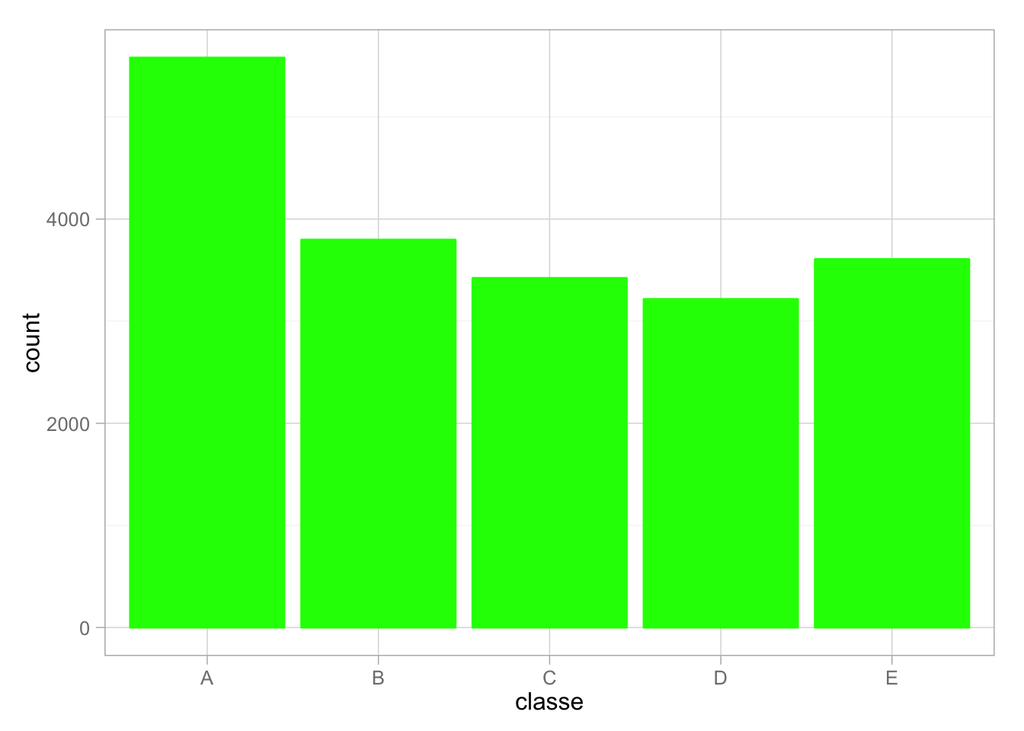

```r
qplot(classe, data=training, fill=I("green"), color=I("green")) + theme_light()
```

Let’s refine the data and strip out the insignificant data, and would concenrate on aggregated values which is denoted in the sataset with the word “total”. There are just 4:

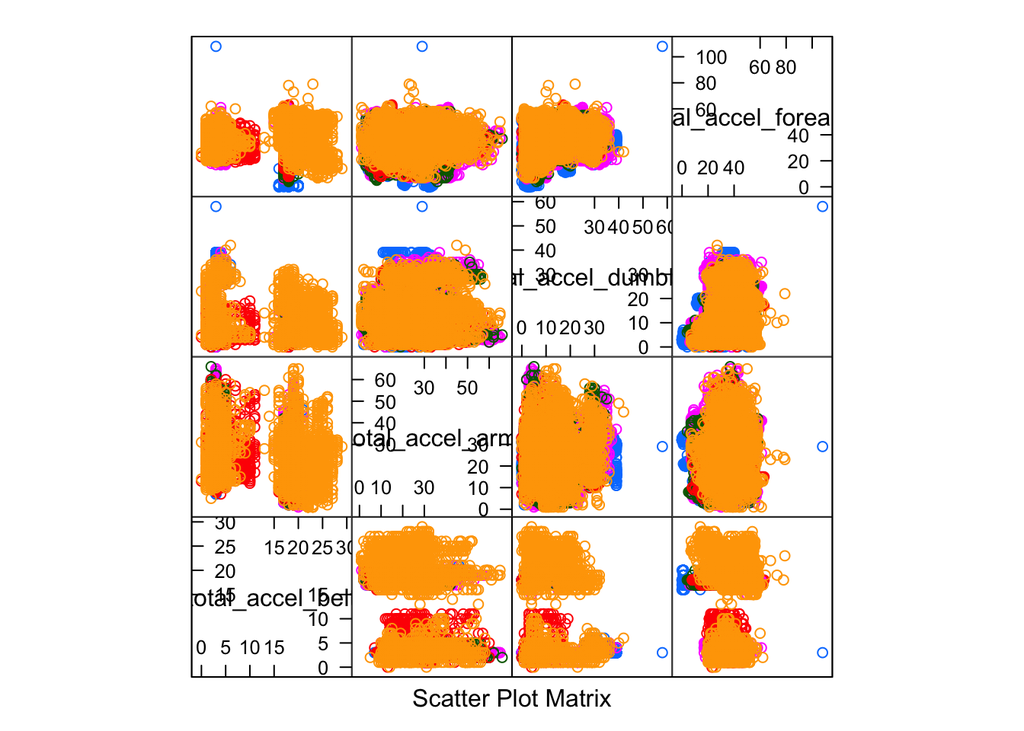

```r
signfcolumns <- colnames(training)[grep("^total", colnames(training))]
featurePlot(training[,signfcolumns], training$classe, plot="pairs")
```

After it, let’s select just high level metrics which start with “roll_…”, “pitch_…”, “yaw_…” and make the plot to check the possible correlation among them. There is no picture with noticeable indication of correlation.

[figure not shown]

```r
cols <- colnames(training)[grep("^[a-z]*_[a-z]*$", colnames(training))][5:16]
featurePlot(training[,cols], training$classe, plot="pairs")
```

# Model training

First model is made using the 4 aggregated metrics, the ramdom forests approach and crossvalidation. The number of folds is set to 10 from consideration of computational performance:

```r
tc <- trainControl(method = "repeatedcv", number = 10)
model1 <- train(classe ~ .,
                data = training[,c(signfcolumns, "classe")],
                method="rf",
                trControl = tc,
                preProc = c("center", "scale"))
model1
```

```
## Random Forest
##
## 19622 samples
##     4 predictor
##     5 classes: 'A', 'B', 'C', 'D', 'E'
##
## Pre-processing: centered (4), scaled (4)
## Resampling: Cross-Validated (10 fold, repeated 1 times)
## Summary of sample sizes: 17661, 17659, 17661, 17660, 17661, 17661, ...
## Resampling results across tuning parameters:
##
##   mtry  Accuracy   Kappa      Accuracy SD  Kappa SD
##   2     0.6924910  0.6103003  0.01254379   0.01586763
##   3     0.6766915  0.5905174  0.01081177   0.01368635
##   4     0.6701172  0.5822626  0.01034810   0.01315425
##
## Accuracy was used to select the optimal model using  the largest value.
## The final value used for the model was mtry = 2.
```

The second is made with the same predictors but with the boosted trees.

```r
model2 <- train(classe ~ .,
                data = training[,c(signfcolumns, "classe")],
                method="bstTree",
                trControl = tc,
                preProc = c("center", "scale"))
model2
```

```
## Boosted Tree
##
## 19622 samples
##     4 predictor
##     5 classes: 'A', 'B', 'C', 'D', 'E'
##
## Pre-processing: centered (4), scaled (4)
## Resampling: Cross-Validated (10 fold, repeated 1 times)
## Summary of sample sizes: 17660, 17660, 17660, 17659, 17659, 17660, ...
## Resampling results across tuning parameters:
##
##   maxdepth  mstop  Accuracy   Kappa       Accuracy SD  Kappa SD
##   1          50    0.2432468  0.04927675  0.004676145  0.005710235
##   1         100    0.2458972  0.05230770  0.005460811  0.006839229
##   1         150    0.2466107  0.05312774  0.004984959  0.006169952
##   2          50    0.2482938  0.05916470  0.010161528  0.010534124
##   2         100    0.2544081  0.06726439  0.006059865  0.007403473
##   2         150    0.2598098  0.07344595  0.006791035  0.008642929
##   3          50    0.2679127  0.08393469  0.006883644  0.008157531
##   3         100    0.2681166  0.08433903  0.006772130  0.007938199
##   3         150    0.2743849  0.09142423  0.006906892  0.008066402
##
## Tuning parameter 'nu' was held constant at a value of 0.1
## Accuracy was used to select the optimal model using  the largest value.
## The final values used for the model were mstop = 150, maxdepth = 3 and
##  nu = 0.1.
```

The third is made using the high level metrics from the dataset and the random forests approach.

```r
model3 <- train(classe ~ .,
                data = training[,c(cols, "classe")],
                method="rf",
                trControl = tc,
                preProc = c("center", "scale"))
model3
```

```
## Random Forest
##
## 19622 samples
##    12 predictor
##     5 classes: 'A', 'B', 'C', 'D', 'E'
##
## Pre-processing: centered (12), scaled (12)
## Resampling: Cross-Validated (10 fold, repeated 1 times)
## Summary of sample sizes: 17661, 17659, 17659, 17660, 17660, 17660, ...
## Resampling results across tuning parameters:
##
##   mtry  Accuracy   Kappa      Accuracy SD  Kappa SD
##    2    0.9887881  0.9858180  0.002961418  0.003745694
##    7    0.9897561  0.9870428  0.002755267  0.003486180
##   12    0.9865962  0.9830466  0.003060593  0.003872651
##
## Accuracy was used to select the optimal model using  the largest value.
## The final value used for the model was mtry = 7.
```

```r
model4 <- train(classe ~ .,
                data = training[,c(cols, "classe")],
                method="bstTree",
                trControl = tc,
                preProc = c("center", "scale"))
model4
```

```
## Boosted Tree
##
## 19622 samples
##    12 predictor
##     5 classes: 'A', 'B', 'C', 'D', 'E'
##
## Pre-processing: centered (12), scaled (12)
## Resampling: Cross-Validated (10 fold, repeated 1 times)
## Summary of sample sizes: 17660, 17659, 17661, 17660, 17660, 17658, ...
## Resampling results across tuning parameters:
##
##   maxdepth  mstop  Accuracy   Kappa      Accuracy SD  Kappa SD
##   1          50    0.2966560  0.1173491  0.006370808  0.007507444
##   1         100    0.2966560  0.1173491  0.006370808  0.007507444
##   1         150    0.2966560  0.1173491  0.006370808  0.007507444
##   2          50    0.3070019  0.1288585  0.005611916  0.006641436
##   2         100    0.3307523  0.1562966  0.008695172  0.010218224
##   2         150    0.3505234  0.1793008  0.010211007  0.012017705
##   3          50    0.3395166  0.1660126  0.005883524  0.007090825
##   3         100    0.3702992  0.2026119  0.009338291  0.011109844
##   3         150    0.3801354  0.2141622  0.008038351  0.009565628
##
## Tuning parameter 'nu' was held constant at a value of 0.1
## Accuracy was used to select the optimal model using  the largest value.
## The final values used for the model were mstop = 150, maxdepth = 3 and
##  nu = 0.1.
```

# Model training overview

Looks like the model based on the high level metrics with the random tree apprcoch shows the best results. It’s accuracy archived 99% when the model with the boosted trees in the best case close to 0.38.  
The dependecy between theoretical accuracy and predictors is shown on the following plot:

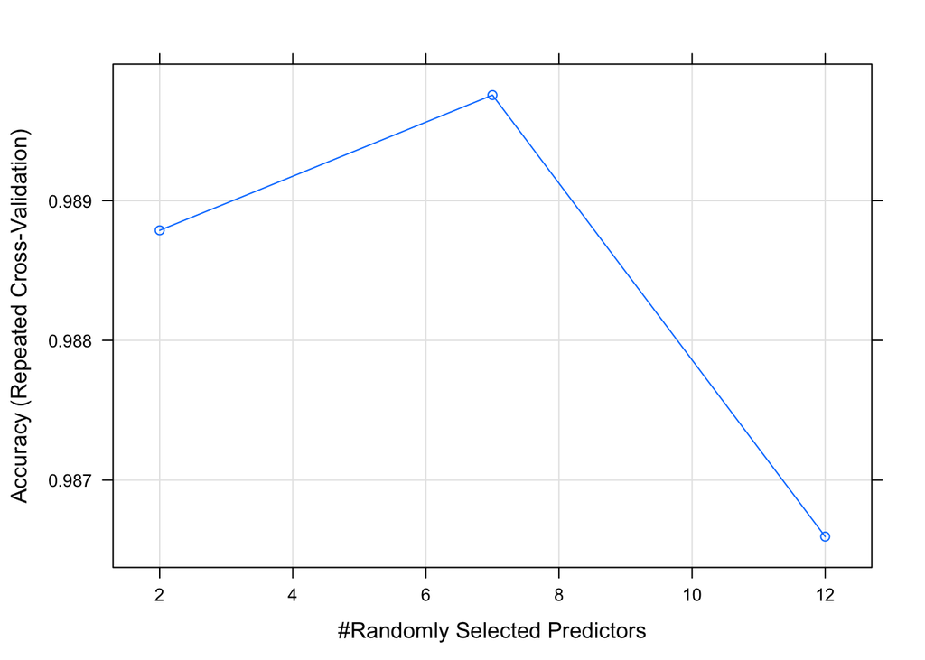

```r
plot(model3)
```

Let’s apply the model 3 to the test set:

```r
predict(model3, newdata=testing[,cols])
```

```
##  [1] B A B A A E D B A A B C B A E E A B B B
## Levels: A B C D E
```

# Conclusion

In the research 4 models were built to predict the activity type. 2 of them were done using the random forests approach and 2 with boosted trees. For first two the total metrics were used as the predictors and the rest the high level metrics. Generally, the performence of models were higher on the provided dataset then on the model with the boosted trees. Also, the model with 12 predictors are better then with 4, however, more computational resourse consuming.